# Demo

This `FILICA` R package conducts the Full Information Linked ICA algorithm (FI-LICA) to handle the missing data problem in multimodal fusion under the LICA framework.

# About

In this file, we will demonstrate the implementation of FI-LICA, as well as LICA, in R, under both MAR and MCAR settings.

*Note:*

- LICA is implemented using [MATLAB functions](https://fsl.fmrib.ox.ac.uk/fsl/fslwiki/FLICA), which will be called from R
- All the MATLAB functions and code scripts are in the folder `./MATLAB_code/flica` from our [GitHub website](https://github.com/ruiyangli1/FILICA)
  - MATLAB scripts to be called from R to run LICA are named as `code_*.m` (i.e., `code_completer.m`, `code_filica_update.m`, `code_nomiss.m`, `code_replace0.m`). *Please make sure to change the path to `your path/FILICA/MATLAB_code/flica` in each script based on your folder location! Details in the User guideline section below.*
- *Caution*: DO NOT run FI-LICA and completer case analysis at the same time as code will interfere with each other!

# User guideline

- Create a new folder in your computer, named as `FILICA`, and set the working directory of R at the current `FILICA` folder
- Download the `./MATLAB_code/flica` folder from our [GitHub website](https://github.com/ruiyangli1/FILICA), and place it under the `FILICA` folder
- Open the following MATLAB scripts in the `FILICA/MATLAB_code/flica` folder: `code_completer.m`, `code_filica_update.m`, `code_nomiss.m`, `code_replace0.m`, and change the path in the first command line to **YOUR PATH`/FILICA/MATLAB_code/flica`** based on your folder location

# Examples

The following demonstrates how to use the functions in our FILICA package.

## Load packages

```r
sessionInfo()[[1]]$version.string
```

```
#> [1] "R version 4.0.3 (2020-10-10)"
```

```r
library(FILICA)

library(tidyverse)
library(scales)      # plot dF curve
breaks_log10 <- function(x) {
  low <- floor(log10(min(x)))
  high <- ceiling(log10(max(x)))
  10^(seq.int(low, high))
}
```

## MCAR setting

- n = 100
- miss 5% of data

### LICA on no-missing data

```r
# -- generate data --
data0 = data_generate_MCAR(nsubj = 100, seed = 7452, n_miss = 5) #--- n_miss doesn't matter b/c will only use no-miss data from data_generate()
# prepare data in lists
data = list(data0$Y1, data0$Y2)

# -- run LICA --
re_nomiss = LICA(data = data, ncomp = 5, niter = 1500, method = "nomiss")
```

```
#> < Running LICA on no-miss data >
#> flica worked.
```

```r
# -- results --
## last dF
last_dF = re_nomiss$F.history[,length(re_nomiss$F.history)]-re_nomiss$F.history[,length(re_nomiss$F.history)-1]
message("Last dF = ", last_dF)
```

```
#> Last dF = 0.0131735944305547
```

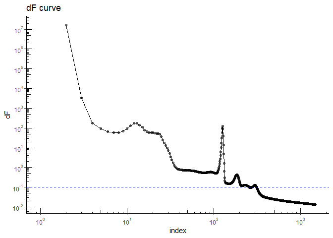

```r
## H
H_nomiss = re_nomiss$H
H_nomiss_trans = t(H_nomiss); colnames(H_nomiss_trans) = paste0("est_comp", 1:ncol(H_nomiss_trans))

## concatenated XW
XWstack_nomiss = do.call(rbind, lapply(1:2, function(k){
  re_nomiss[["X"]][[k]][[1]] %*% diag( as.vector(re_nomiss[["W"]][[k]][[1]]) )
  }))
colnames(XWstack_nomiss) = paste0("est_comp", 1:5)

## dF curve
F_hist = t(re_nomiss$F.history)
F_hist_lag = lag(F_hist)
dF = data.frame(dF = F_hist - F_hist_lag)
dF$index = 1:nrow(dF)
dF %>%
  ggplot(aes(x = index, y = dF)) +
  geom_point(alpha = 0.5) +
  geom_path() +
  annotation_logticks() +
  scale_x_log10(breaks = breaks_log10,labels = trans_format(log10, math_format(10^.x))) +
  scale_y_log10(breaks = breaks_log10,labels = trans_format(log10, math_format(10^.x))) +
  labs(title = "dF curve") +
  geom_hline(yintercept = 0.1, linetype = "dashed", color = "blue") +
  theme_classic()
```

```r
## best-matching component
## truth
XWstack_true = rbind(data0$XW1, data0$XW2)
H_true = data0$H
H_true_trans = t(H_true); colnames(H_true_trans) = paste0("true_comp", 1:ncol(H_true_trans))
## XW
best = bestIC(XWstack_true, XWstack_nomiss)
## H
best_H = H_nomiss_trans[,paste0("est_",best[,"best_match"])]
cor_H = cor(H_true_trans, best_H)
## output
out = cbind(best, H_cor = as.numeric(diag(cor_H))) %>% as.data.frame() %>% mutate_at(3:4, as.numeric)
colnames(out)[3] = "XW_cor"
out
```

```
#>     ref_comp best_match     XW_cor      H_cor
#> 1 true_comp1      comp2 -0.6705397 -0.6162133
#> 2 true_comp2      comp1 -0.6938415 -0.8020613
```

### LICA on data after replacing missing with 0

```r
# -- generate data --
data0 = data_generate_MCAR(nsubj = 100, seed = 7452, n_miss = 5)
# prepare data in lists
data = list(data0$Y1_miss, data0$Y2_miss)

# -- run LICA --
re_replace0 = LICA(data = data, ncomp = 5, niter = 1500, method = "replace0")
```

```
#> < Running current practice: replace NA with 0 + LICA >
#> flica worked.
```

```r
# in case LICA stop early (e.g., n_miss=20), reduce flica_niter (by 25%) and rerun LICA until it works
# stop if reduce 18 times but still not work
flica_niter_used = 1500
stop_count = 1
while (class(re_replace0) == "try-error" & stop_count <= 18) {
  flica_niter_used = ceiling(0.75 * flica_niter_used)
  message("< Re-running LICA > ( ", flica_niter_used, " iterations )")
  re_replace0 = LICA(data = data, ncomp = 5, niter = flica_niter_used, method = "replace0")
  stop_count = stop_count + 1
}


# -- results --
## last dF
last_dF = re_replace0$F.history[,length(re_replace0$F.history)]-re_replace0$F.history[,length(re_replace0$F.history)-1]
message("Last dF = ", last_dF)
```

```
#> Last dF = 9.70145389117533
```

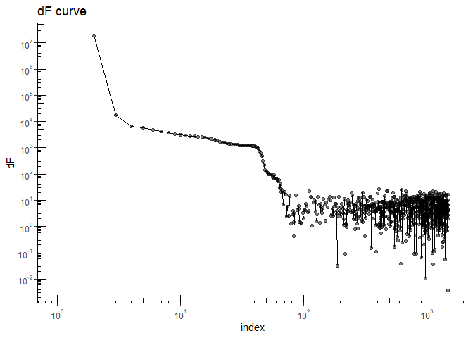

```r
## H
H_replace0 = re_replace0$H
H_replace0_trans = t(H_replace0); colnames(H_replace0_trans) = paste0("est_comp", 1:ncol(H_replace0_trans))

## concatenated XW
XWstack_replace0 = do.call(rbind, lapply(1:2, function(k){
  re_replace0[["X"]][[k]][[1]] %*% diag( as.vector(re_replace0[["W"]][[k]][[1]]) )
  }))
colnames(XWstack_replace0) = paste0("est_comp", 1:5)

## dF curve
F_hist = t(re_replace0$F.history)
F_hist_lag = lag(F_hist)
dF = data.frame(dF = F_hist - F_hist_lag)
dF$index = 1:nrow(dF)
dF %>%
  ggplot(aes(x = index, y = dF)) +
  geom_point(alpha = 0.5) +
  geom_path() +
  annotation_logticks() +
  scale_x_log10(breaks = breaks_log10,labels = trans_format(log10, math_format(10^.x))) +
  scale_y_log10(breaks = breaks_log10,labels = trans_format(log10, math_format(10^.x))) +
  labs(title = "dF curve") +
  geom_hline(yintercept = 0.1, linetype = "dashed", color = "blue") +
  theme_classic()
```

```r
## best-matching component
## truth
XWstack_true = rbind(data0$XW1, data0$XW2)
H_true = data0$H
H_true_trans = t(H_true); colnames(H_true_trans) = paste0("true_comp", 1:ncol(H_true_trans))
## XW
best = bestIC(XWstack_true, XWstack_replace0)
## H
best_H = H_replace0_trans[,paste0("est_",best[,"best_match"])]
cor_H = cor(H_true_trans, best_H)
## output
out = cbind(best, H_cor = as.numeric(diag(cor_H))) %>% as.data.frame() %>% mutate_at(3:4, as.numeric)
colnames(out)[3] = "XW_cor"
out
```

```
#>     ref_comp best_match     XW_cor      H_cor
#> 1 true_comp1      comp2 -0.7422960 -0.6333600
#> 2 true_comp2      comp1 -0.7342852 -0.8413855
```

### LICA on completers

```r
# -- generate data --
data0 = data_generate_MCAR(nsubj = 100, seed = 7452, n_miss = 5)
# prepare data in lists
data = list(data0$Y1_miss, data0$Y2_miss)

# -- run LICA --
re_completer = LICA(data = data, ncomp = 5, niter = 1500, method = "completer")
```

```
#> < Running LICA on completers >
#> flica worked.
```

```r
# -- results --
## last dF
last_dF = re_completer$F.history[,length(re_completer$F.history)]-re_completer$F.history[,length(re_completer$F.history)-1]
message("Last dF = ", last_dF)
```

```
#> Last dF = 0.0162169437971897
```

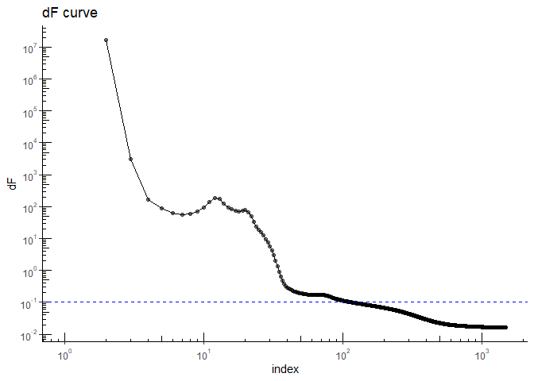

```r
## H
H_completer = re_completer$H
H_completer_trans = t(H_completer); colnames(H_completer_trans) = paste0("est_comp", 1:ncol(H_completer_trans))

## concatenated XW
XWstack_completers = do.call(rbind, lapply(1:2, function(k){
  re_completer[["X"]][[k]][[1]] %*% diag( as.vector(re_completer[["W"]][[k]][[1]]) )
  }))
colnames(XWstack_completers) = paste0("est_comp", 1:5)

## dF curve
F_hist = t(re_completer$F.history)
F_hist_lag = lag(F_hist)
dF = data.frame(dF = F_hist - F_hist_lag)
dF$index = 1:nrow(dF)
dF %>%
  ggplot(aes(x = index, y = dF)) +
  geom_point(alpha = 0.5) +
  geom_path() +
  annotation_logticks() +
  scale_x_log10(breaks = breaks_log10,labels = trans_format(log10, math_format(10^.x))) +
  scale_y_log10(breaks = breaks_log10,labels = trans_format(log10, math_format(10^.x))) +
  labs(title = "dF curve") +
  geom_hline(yintercept = 0.1, linetype = "dashed", color = "blue") +
  theme_classic()
```

```r
## best-matching component
## truth
XWstack_true = rbind(data0$XW1, data0$XW2)
H_true = data0$H
H_true_trans = t(H_true); colnames(H_true_trans) = paste0("true_comp", 1:ncol(H_true_trans))
## XW
best = bestIC(XWstack_true, XWstack_completers)
## H
best_H = H_completer_trans[,paste0("est_",best[,"best_match"])]
all_miss_subj = sort(c(data0$subj1_miss,data0$subj2_miss))
cor_H = cor(H_true_trans[-all_miss_subj,], best_H)
## output
out = cbind(best, H_cor = as.numeric(diag(cor_H))) %>% as.data.frame() %>% mutate_at(3:4, as.numeric)
colnames(out)[3] = "XW_cor"
out
```

```
#>     ref_comp best_match     XW_cor      H_cor
#> 1 true_comp1      comp1  0.6754353  0.8092848
#> 2 true_comp2      comp2 -0.6975972 -0.6220104
```

### FI-LICA

- Results from the completer cases analysis (`completer_results_saved_from_FILICA`) will also be stored at the Environment during the process.

```r
# -- generate data --
data0 = data_generate_MCAR(nsubj = 100, seed = 7452, n_miss = 5)
# subjects with missing -- will be automatically identified by FI_LICA() if not provided
## Note: different missing subjects orders will lead to different results due to noise matrix added in step 2
subj_miss = list(data0$subj1_miss, data0$subj2_miss)
# prepare data in lists
data = list(data0$Y1_miss, data0$Y2_miss)

# -- run FI-LICA --
re_filica = FI_LICA(data = data, ncomp = 5, flica_niter = 1500, n = 20, flica_niter2 = 1000, rescale = TRUE, re_completer = NULL)
```

```
#> < -- FI-LICA Step 0: Data Preparation -- >
#> Done.
#> < -- FI-LICA Step 1: Initialization -- >
#> < Running LICA on completers >
#> flica worked.
#> Last dF = 0.0162169437971897
#> FI-LICA step 1 started.
#> Done.
#> < -- FI-LICA Step 2: Optimization ( 20 updates ) -- >
#> FI-LICA step 2 started.
#> Update 1 started.
#> flica worked.
#> XW convergence = 23.2083532910005
#> H convergence = 144.932932498003
#> Done.
#> Update 2 started.
#> flica worked.
#> XW convergence = 2.78976341543306
#> H convergence = 2.46638790130794
#> Done.
#> Update 3 started.
#> flica worked.
#> XW convergence = 2.27869041285509
#> H convergence = 2.30204126610187
#> Done.
#> Update 4 started.
#> flica worked.
#> XW convergence = 2.17493413583827
#> H convergence = 1.66960250939819
#> Done.
#> Update 5 started.
#> flica worked.
#> XW convergence = 2.17895199800777
#> H convergence = 1.25016061538971
#> Done.
#> Update 6 started.
#> flica worked.
#> XW convergence = 2.20512888307868
#> H convergence = 1.12595709587499
#> Done.
```

[output cut: 57 more lines]

```
#> XW convergence = 2.51913388014321
#> H convergence = 0.346705216347488
#> Done.
#> Update 19 started.
#> flica worked.
#> XW convergence = 2.53335658639216
#> H convergence = 0.293885629162765
#> Done.
#> Update 20 started.
#> flica worked.
#> XW convergence = 2.54580471961495
#> H convergence = 0.251746717149756
#> Done.
#> FI-LICA step 2 done.
## or if want to use the saved results from completer case analysis: re_filica = FI_LICA(data = data, ncomp = 5, flica_niter = 1500, n = 20, flica_niter2 = 1000, rescale = TRUE, re_completer = re_completer)
```

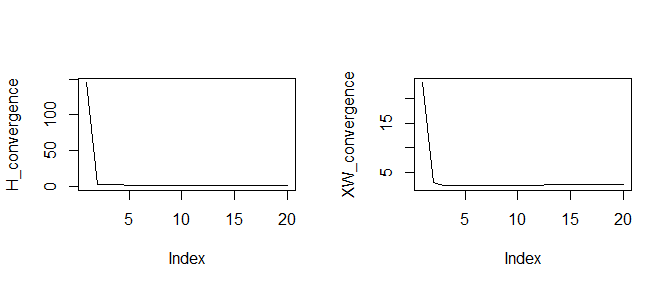

```r
# -- results --
## number of modality
mod_n = length(re_filica$results[["X"]])
## H
H_filica = re_filica$results$H
H_filica_trans = t(H_filica); colnames(H_filica_trans) = paste0("est_comp", 1:ncol(H_filica_trans))
## concatenated XW
XW_filica = do.call(rbind, lapply(1:mod_n, function(k){
  re_filica$results[["X"]][[k]][[1]] %*% diag( as.vector(re_filica$results[["W"]][[k]][[1]]) )
  }))
colnames(XW_filica) = paste0("est_comp", 1:5)

## convergence
par(mfrow=c(1,2))
plot(re_filica$H_convergence, ylab = "H_convergence", type="l")
plot(re_filica$XW_convergence, ylab = "XW_convergence", type="l")
```

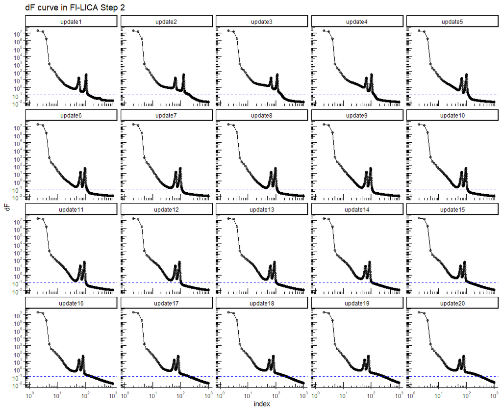

```r
## dF curve
F_hist = re_filica$F_hist
F_hist_lag = lag(F_hist)
dF = data.frame(F_hist - F_hist_lag)
colnames(dF) = paste0("update", 1:20)
dF$index = 1:nrow(dF)
dF %>%
  pivot_longer(1:20, names_to = "update", values_to = "dF") %>%
  mutate(update = factor(update,levels = paste0("update",1:20))) %>%
  filter(update %in% c(paste0("update",1:20))) %>%
  ggplot(aes(x = index, y = dF)) +
  geom_point(alpha = 0.5) +
  geom_path() +
  facet_wrap(~update) +
  annotation_logticks() +
  scale_x_log10(breaks = breaks_log10,labels = trans_format(log10, math_format(10^.x))) +
  scale_y_log10(breaks = breaks_log10,labels = trans_format(log10, math_format(10^.x))) +
  labs(title = "dF curve in FI-LICA Step 2") +
  geom_hline(yintercept = 0.1, linetype = "dashed", color = "blue") +
  theme_classic()
```

```r
## best-matching component
## truth
XWstack_true = rbind(data0$XW1, data0$XW2)
H_true = data0$H
H_true_trans = t(H_true); colnames(H_true_trans) = paste0("true_comp", 1:ncol(H_true_trans))
## XW
best = bestIC(XWstack_true, XW_filica)
## H
best_H = H_filica_trans[,paste0("est_",best[,"best_match"])]
cor_H = cor(H_true_trans, best_H)
## output
out = cbind(best, H_cor = as.numeric(diag(cor_H))) %>% as.data.frame() %>% mutate_at(3:4, as.numeric)
colnames(out)[3] = "XW_cor"
out
```

```
#>     ref_comp best_match     XW_cor      H_cor
#> 1 true_comp1      comp1  0.7167103  0.8329725
#> 2 true_comp2      comp2 -0.7237331 -0.6659301
```

## MAR setting (continuous H)

- n = 100
- miss 5% of data
- same code as above, expect using `data_generate_MAR_ctnsH()` instead of `data_generate_MCAR()` for data generation

## MAR setting (mixed H)

- n = 100
- miss 5% of data
- same code as above, expect using `data_generate_MAR`() instead of `data_generate_MCAR()` for data generation